# Hackathon2-Sberbank Russian Housing Market Data Analysis and Visuvalization

shashikant dewangan

18 January 2018

```r
library(data.table)# read data with fread()
library(tidyverse)# packages that work in harmony
library(lubridate)#Make Dealing with Dates a Little Easier
library(scales)#for automatically determining breaks and labels
```

```r
library(corrplot)# for correlation
library(DT)#Wrapper of the JavaScript Library 'DataTables'
```

```r
train <- fread("file:///C:/Users/Administrator/Desktop/Kaggle/pucho1/train.csv")
```

```
##
Read 65.6% of 30471 rows
Read 98.5% of 30471 rows
Read 30471 rows and 292 (of 292) columns from 0.044 GB file in 00:00:04
```

```r
colnames(train)
```

```
##   [1] "id"
##   [2] "timestamp"
##   [3] "full_sq"
##   [4] "life_sq"
##   [5] "floor"
##   [6] "max_floor"
##   [7] "material"
##   [8] "build_year"
##   [9] "num_room"
##  [10] "kitch_sq"
##  [11] "state"
##  [12] "product_type"
##  [13] "sub_area"
##  [14] "area_m"
##  [15] "raion_popul"
```

[output cut: 277 more lines]

```r
str(train)
```

```
## Classes 'data.table' and 'data.frame':   30471 obs. of  292 variables:
##  $ id                                   : int  1 2 3 4 5 6 7 8 9 10 ...
##  $ timestamp                            : chr  "20-08-2011" "23-08-2011" "27-08-2011" "01-09-2011" ...
##  $ full_sq                              : int  43 34 43 89 77 67 25 44 42 36 ...
##  $ life_sq                              : int  27 19 29 50 77 46 14 44 27 21 ...
##  $ floor                                : int  4 3 2 9 4 14 10 5 5 9 ...
##  $ max_floor                            : int  NA NA NA NA NA NA NA NA NA NA ...
##  $ material                             : int  NA NA NA NA NA NA NA NA NA NA ...
##  $ build_year                           : int  NA NA NA NA NA NA NA NA NA NA ...
##  $ num_room                             : int  NA NA NA NA NA NA NA NA NA NA ...
##  $ kitch_sq                             : int  NA NA NA NA NA NA NA NA NA NA ...
##  $ state                                : int  NA NA NA NA NA NA NA NA NA NA ...
##  $ product_type                         : chr  "Investment" "Investment" "Investment" "Investment" ...
##  $ sub_area                             : chr  "Bibirevo" "Nagatinskij Zaton" "Tekstil'shhiki" "Mitino" ...
##  $ area_m                               : num  6407578 9589337 4808270 12583536 8398461 ...
```

[output cut: 87 more lines]

EDA : Missing Data

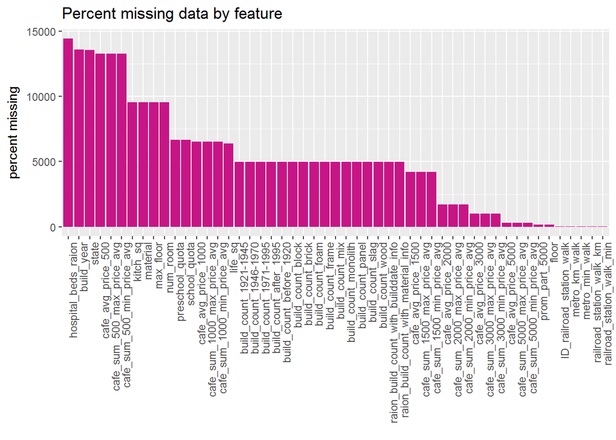

```r
miss_value=sort(colSums(is.na(train)))
miss_value <- miss_value[miss_value>0]
data.frame(miss=miss_value, var=names(miss_value), row.names=NULL) %>%
    ggplot(aes(x=reorder(var, -miss), y=miss)) +
    geom_bar(stat='identity', fill='mediumvioletred') +
    labs(x='', y='percent missing', title='Percent missing data by feature') +
    theme(axis.text.x=element_text(angle=90, hjust=1))
```

```r
train$state[which(is.na(train$state))] <- 2 # mode value
train$build_year[which(is.na(train$build_year))] <- 2014 # mode value
```

Corelation between Numeric Columns

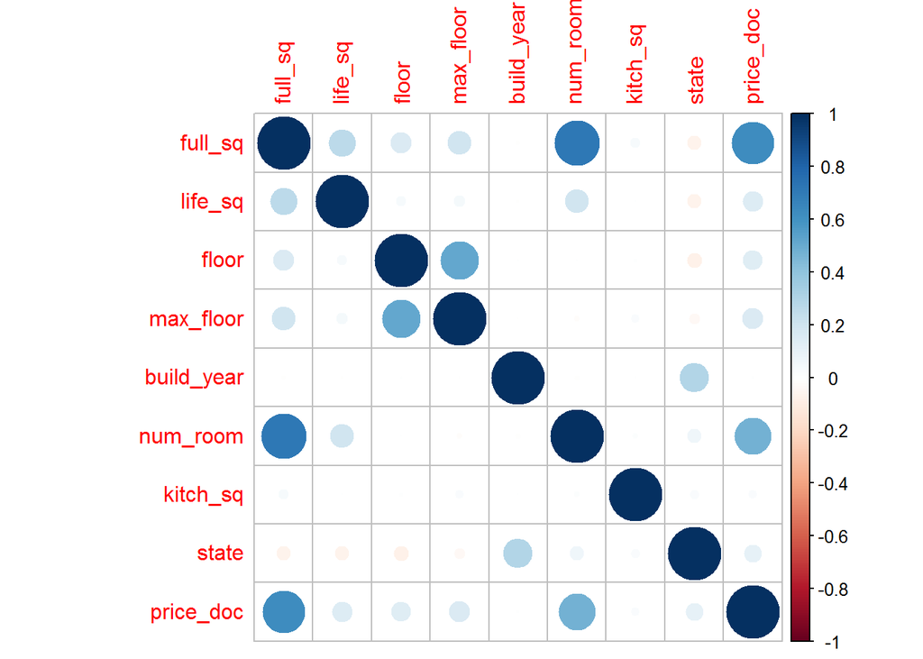

```r
cor_values <- c('full_sq', 'life_sq', 'floor', 'max_floor', 'build_year', 'num_room',
                    'kitch_sq', 'state', 'price_doc')

corrplot(cor(train[, ..cor_values], use="complete.obs"))
```

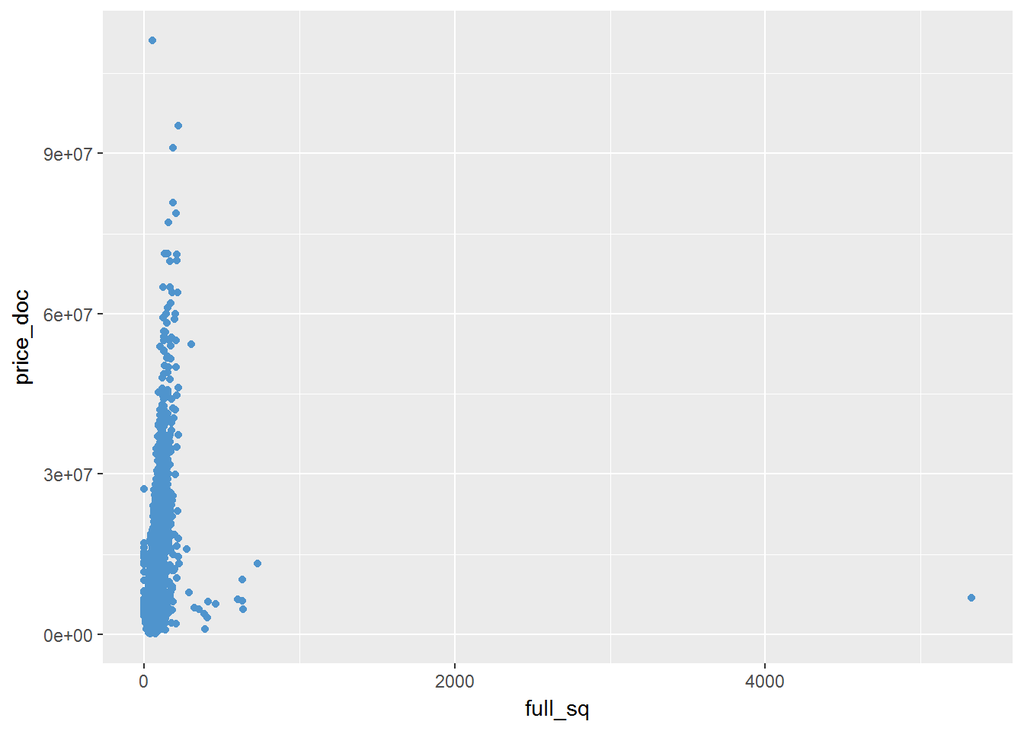

```r
# Here Price and size of Home highly corelated
ggplot(aes(x=full_sq, y=price_doc), data=train) +
    geom_point(color='steelblue3')
```

There is an outlier in full_sq. Its not clear whether this is an entry error. For now, remove it.

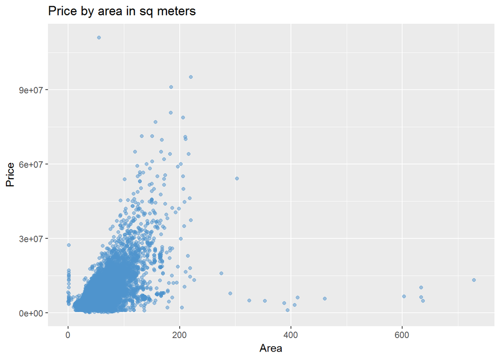

```r
train %>%
    filter(full_sq < 2000) %>%
    ggplot(aes(x=full_sq, y=price_doc)) +
    geom_point(color='steelblue3', alpha=0.5) +
    labs(x='Area', y='Price', title='Price by area in sq meters')
```

Analysisig The Count by Room in a House

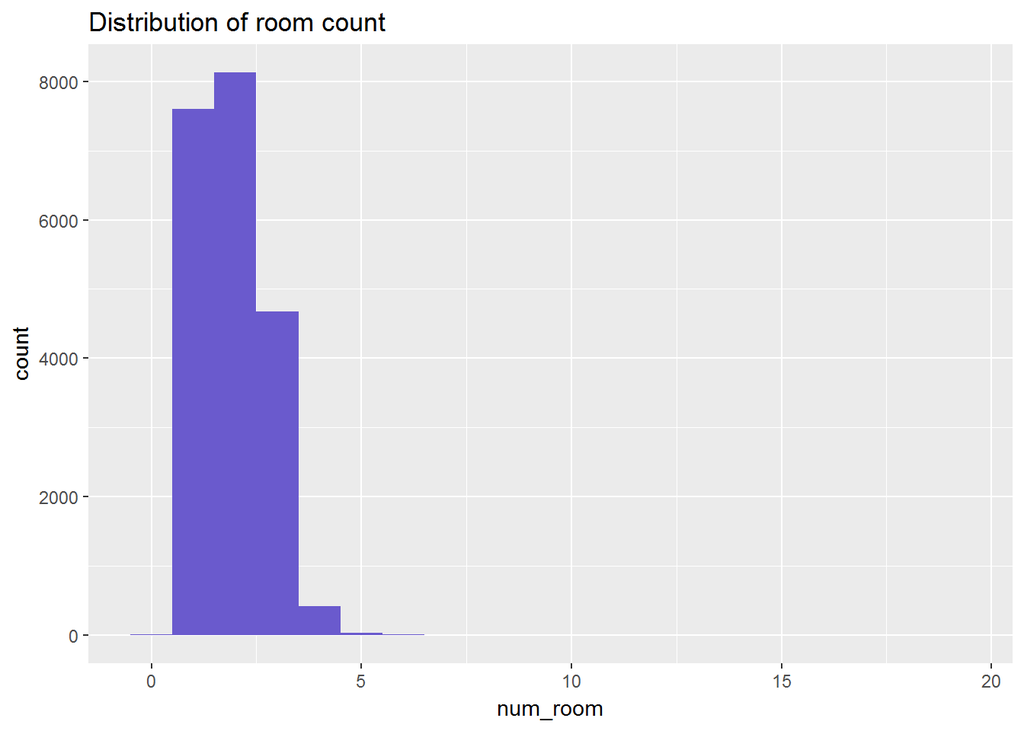

```r
ggplot(aes(x=num_room), data=train) +
    geom_histogram(fill='slateblue', bins=20) +
    ggtitle('Distribution of room count')
```

Sale Distribution of Home by a inverter

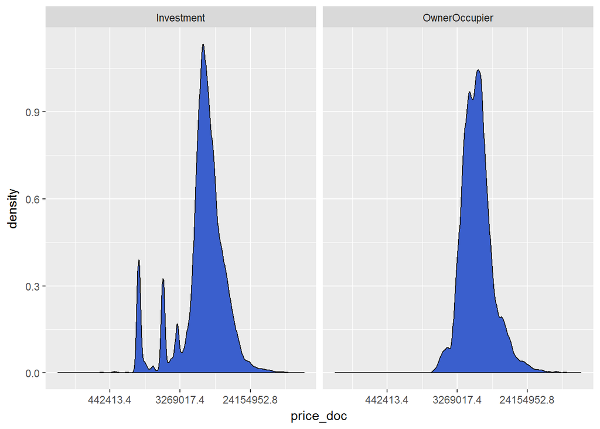

```r
ggplot(aes(x=price_doc), data=train) +
    geom_density(fill='royalblue3', color='gray10') +
    facet_grid(~product_type) +
    scale_x_continuous(trans='log')
```

House Build Year Wise

```r
table(train$build_year)
```

```
##
##        0        1        3       20       71      215     1691     1860
##      530      368        2        1        1        1        1        2
##     1876     1886     1890     1895     1896     1900     1904     1905
##        1        1        5        1        2        2        1        1
##     1906     1907     1910     1911     1912     1914     1915     1917
##        1        2        5        1        5        3        5       16
##     1920     1924     1925     1926     1927     1928     1929     1930
##        1        3        1        8       10       12       12        6
##     1931     1932     1933     1934     1935     1936     1937     1938
##        6        8        7       13       11        5       10        9
##     1939     1940     1941     1943     1946     1947     1948     1949
##        7       14        2        2        2        4        1        3
##     1950     1951     1952     1953     1954     1955     1956     1957
##       22       23       45       24       36       52       48      119
```

[output cut: 16 more lines]

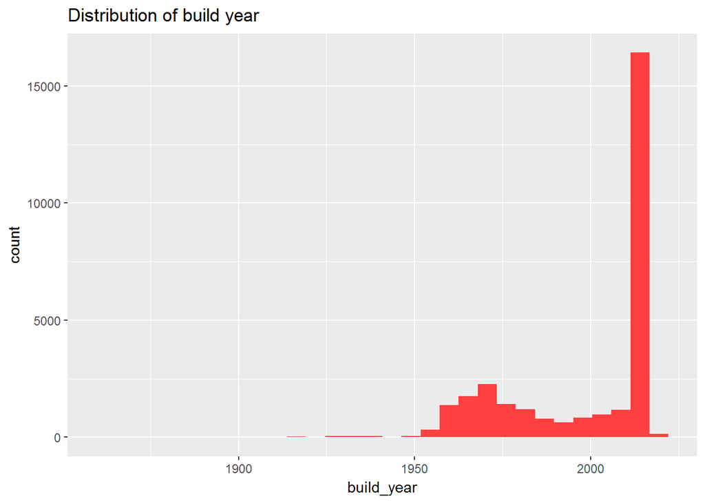

```r
train %>%
    filter(build_year > 1691 & build_year < 2018) %>%
    ggplot(aes(x=build_year)) +
    geom_histogram(fill='brown1') +
    ggtitle('Distribution of build year')
```

Mean Price by Year of build

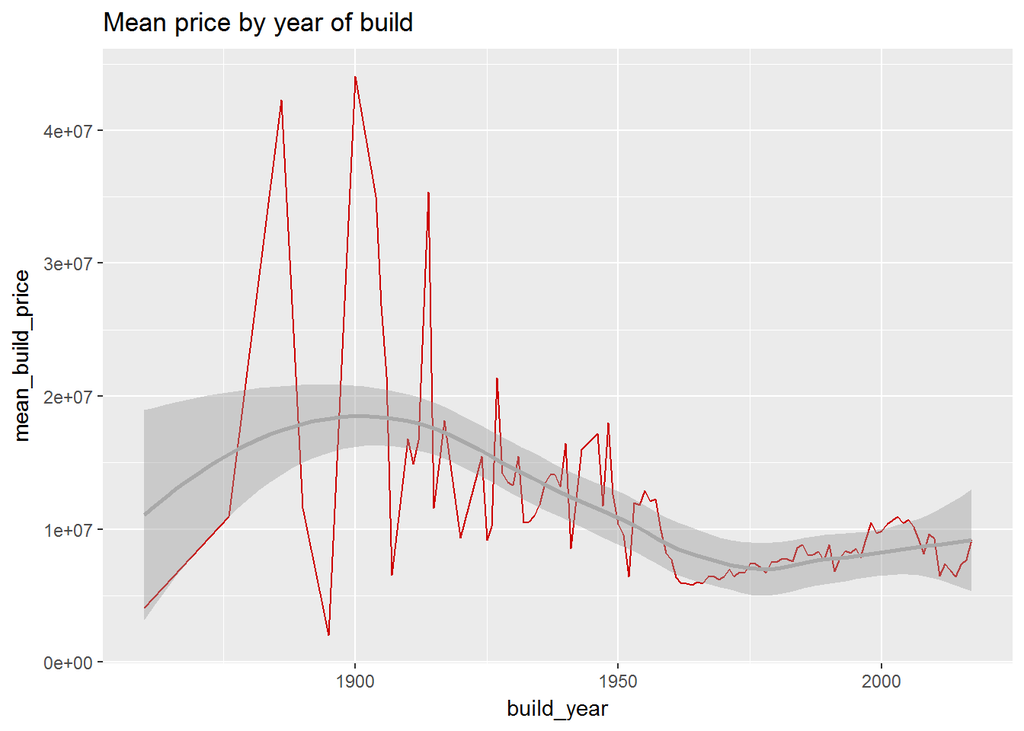

```r
train %>%
    filter(build_year > 1691 & build_year < 2018) %>%
    group_by(build_year) %>%
    summarize(mean_build_price=mean(price_doc)) %>%
    ggplot(aes(x=build_year, y=mean_build_price)) +
    geom_line(stat='identity', color='red3') +
    geom_smooth(color='darkgrey') +
    ggtitle('Mean price by year of build')
```

Timestamp How does the sale price vary over the time horizon of the data set? Here I just group by the day and calculate the median price for each day and plot it over time.

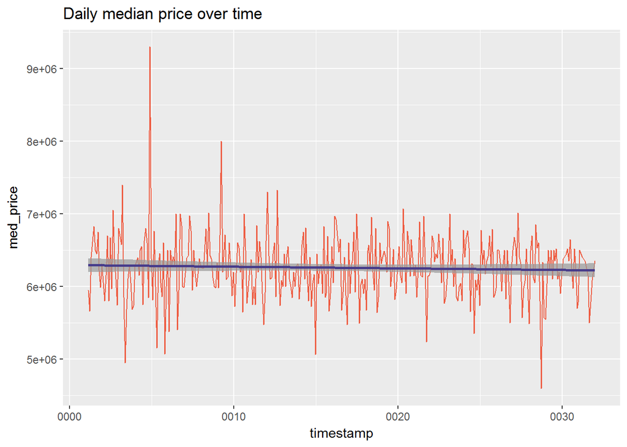

```r
train$timestamp <- as.Date(train$timestamp)

train %>%
    group_by(timestamp) %>%
    summarize(med_price = median(price_doc)) %>%
    ggplot(aes(x = timestamp, y = med_price)) +
    geom_line(color = 'tomato2') +
    geom_smooth(method = 'lm', color = 'slateblue4', alpha = 0.7) +
    ggtitle('Daily median price over time')
```

And to compare with the above plot, here is the volume of sales over the same time.

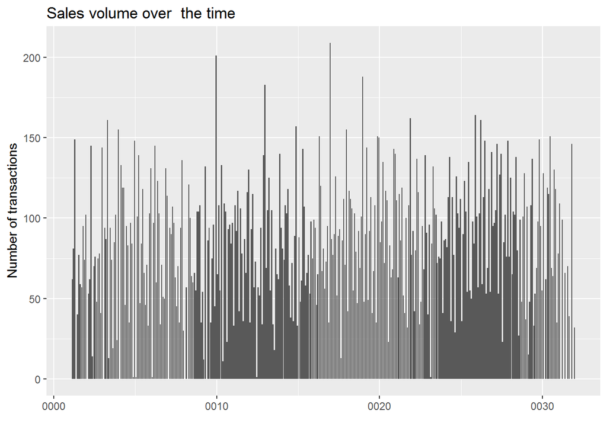

```r
train %>%
    group_by(timestamp) %>%
    summarize(n = n()) %>%
    ggplot(aes(x = timestamp, y = n)) +
    geom_bar(stat = 'identity') +
    labs(x='', y='Number of transactions', title='Sales volume over  the time')
```

Checking is there a seasonal component to home prices in the course of a year?

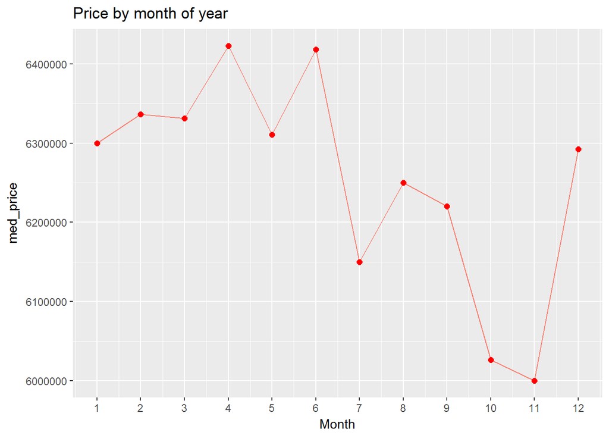

```r
train %>%
    mutate(month=month(timestamp)) %>%
    group_by(month) %>%
    summarize(med_price=median(price_doc)) %>%
    ggplot(aes(x=as.integer(month), y=med_price)) +
    geom_line(color='salmon', stat='identity') +
    geom_point(color='red', size=2) +
    scale_x_continuous(breaks=seq(1,12,1)) +
    labs(x='Month', title='Price by month of year')
```

Home State/Material How do homes vary in price by condition

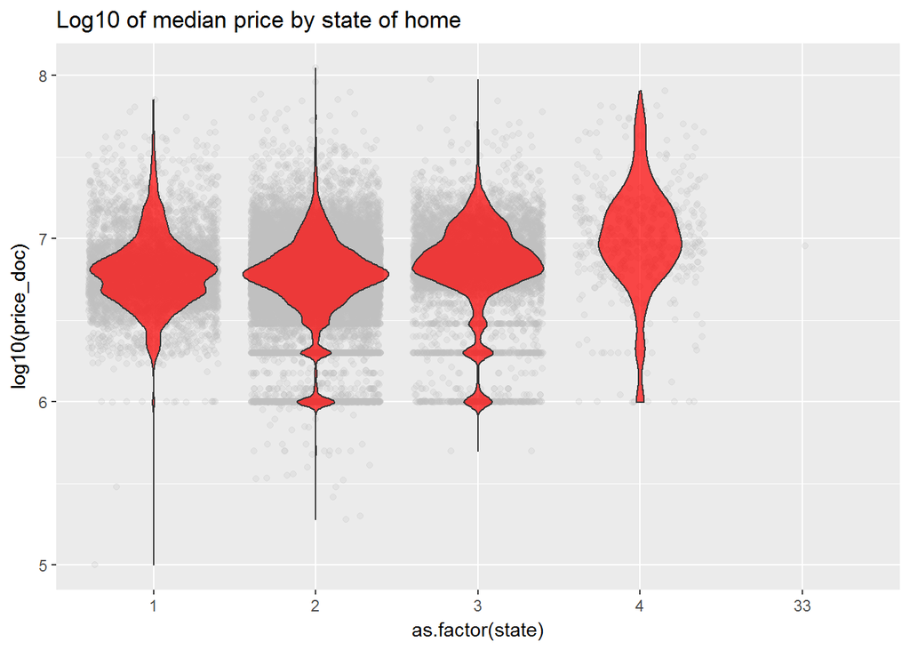

```r
train %>%
filter(!is.na(state)) %>%
    ggplot(aes(x=as.factor(state), y=log10(price_doc))) +
    geom_jitter(color='grey', alpha=0.2) +
    geom_violin(fill='red', alpha=0.7) +
    ggtitle('Log10 of median price by state of home')
```

tha state 4 has the highest sale price on average. Significantly fewer homes fall under this category however

```r
train %>%
    filter(!is.na(state)) %>%
    group_by(state) %>%
    summarize(mean(price_doc))
```

```
## # A tibble: 5 x 2
##   state `mean(price_doc)`
##   <dbl>             <dbl>
## 1  1.00           7315440
## 2  2.00           6654399
## 3  3.00           8078316
## 4  4.00          13345469
## 5 33.0            9000000
```

Material Future

```r
table(train$material)
```

```
##
##     1     2     3     4     5     6
## 14197  2993     1  1344  1561   803
```

It’s unclear what these values mean since this feature is not described in the data dictionary. Material 1 is by far the most common. Only one home is classifed as material 3. How does median price compare among these six materials

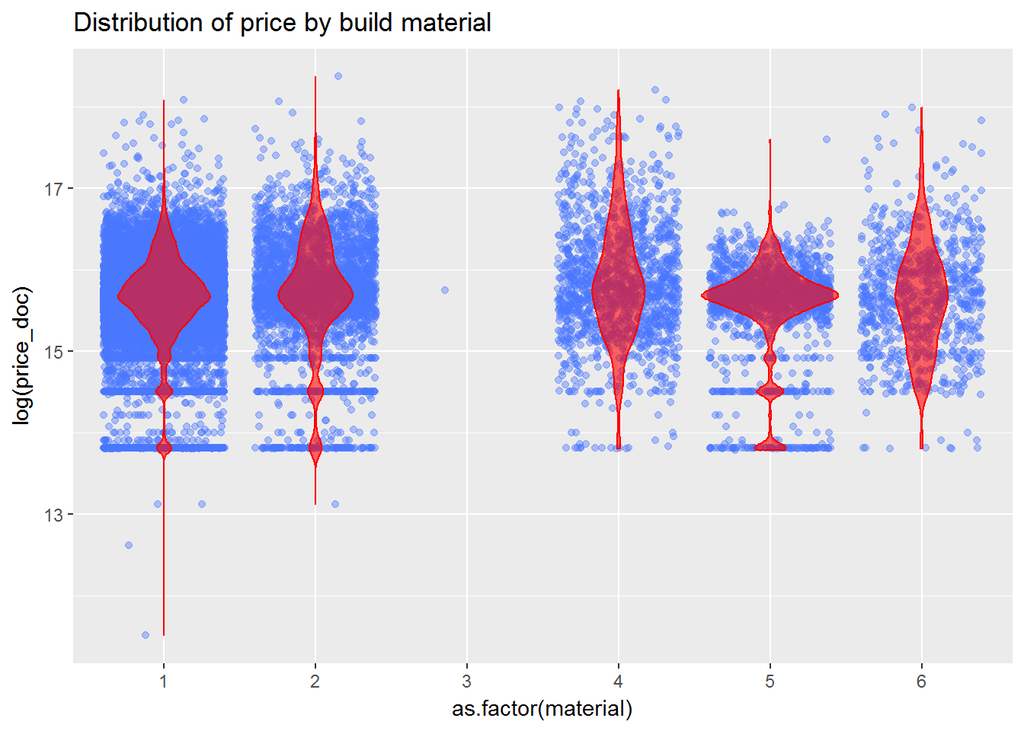

```r
train %>%
    filter(!is.na(material)) %>%
    ggplot(aes(x=as.factor(material), y=log(price_doc))) +
    geom_jitter(alpha=0.4, color='royalblue1') +
    geom_violin(fill='red', color='red',  alpha=0.6) +
    ggtitle('Distribution of price by build material')
```

Floor of Home How does the floor feature compare with price According to the correlation plot from earlier, there is a moderate positive correlation.

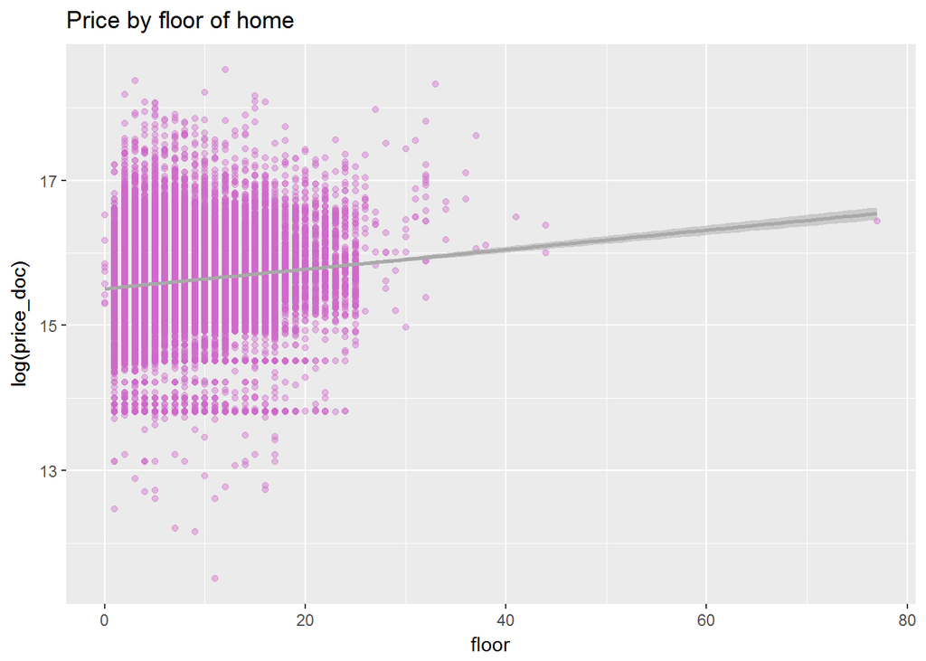

```r
ggplot(aes(x=floor, y=log(price_doc)), data=train) +
      geom_point(color='orchid3', alpha=0.4) +
    geom_smooth(method='lm', color='darkgrey') +
    ggtitle('Price by floor of home')
```

On a whole, price seems to rise with the floor, although the effect is pretty small. Along the same lines, I wonder if the height of building is correlated with price. Well look at this using max_floor as a proxy for height.

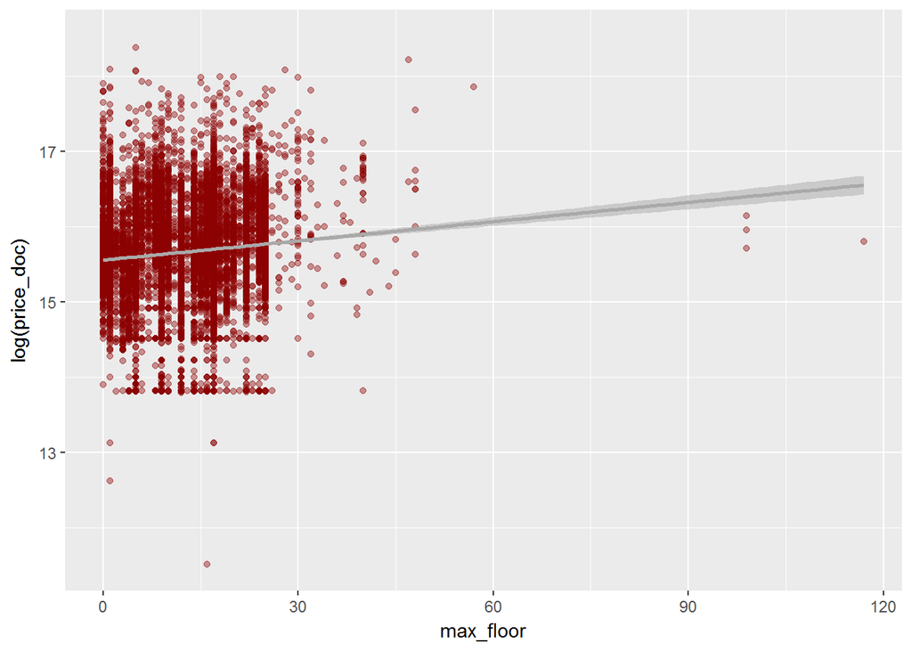

```r
ggplot(aes(x=max_floor, y=log(price_doc)), data=train) +
    geom_point(color='red4', alpha=0.4) +
    geom_smooth(method='lm', color='darkgrey')
```

Let’s check the quality of the data and see if floor is greater than max_floor for any observations:

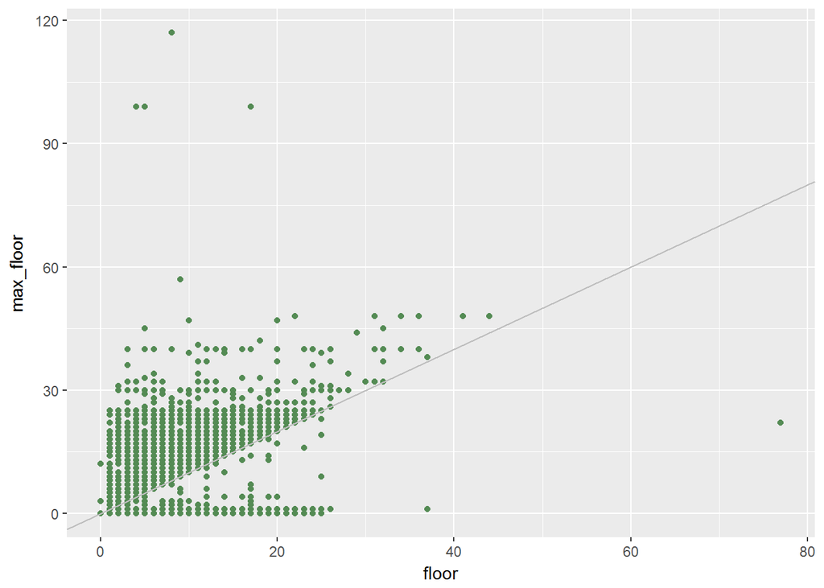

```r
ggplot(aes(x=floor, y=max_floor), data=train) +
    geom_point(color='palegreen4') +
    geom_abline(slope=1, intercept=0, color='grey')
```

The observations below the grey identity line have a floor greater than the number of floors in the building. That’s not good. How many are there?

```r
train %>%
    select(id, floor, max_floor) %>%
    filter(floor > max_floor) %>%
    datatable()
```

|  | id | floor | max_floor |
| --- | --- | --- | --- |
| 1 | 8219 | 13 | 0 |
| 2 | 8271 | 3 | 1 |
| 3 | 8502 | 2 | 0 |
| 4 | 8534 | 7 | 0 |
| 5 | 8915 | 5 | 0 |
| 6 | 9164 | 8 | 3 |
| 7 | 9260 | 8 | 1 |
| 8 | 9312 | 5 | 1 |
| 9 | 9391 | 10 | 1 |
| 10 | 9415 | 4 | 1 |

[output cut: 1483 more lines]

Demographic Characteristics Now let’s move beyond the internal home characteristics and take a look at some of the basic demographic and geographic characteristics. First, the correlation plot.

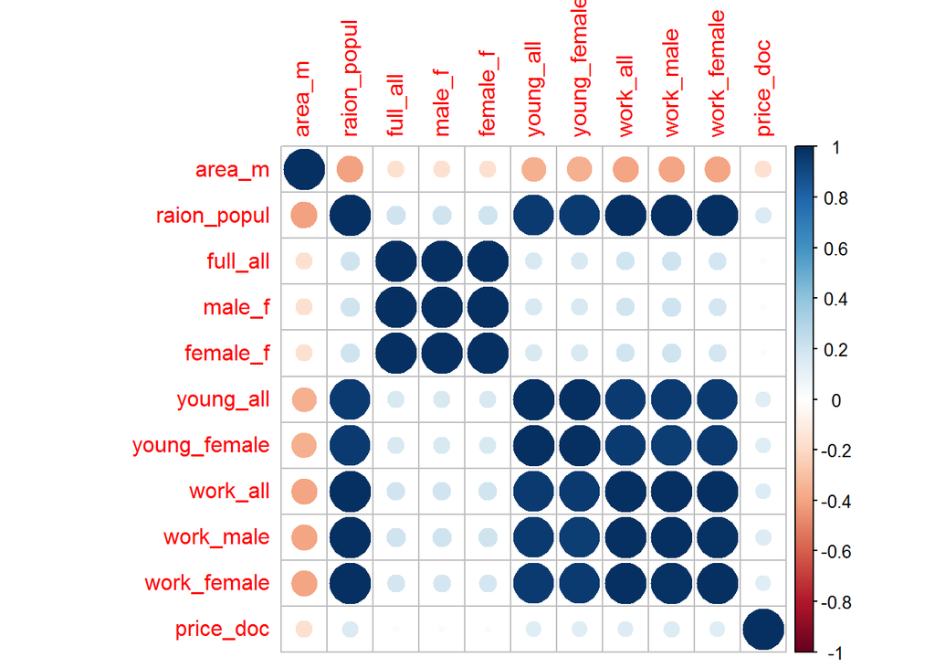

```r
demo_vars <- c('area_m', 'raion_popul', 'full_all', 'male_f', 'female_f', 'young_all',
               'young_female', 'work_all', 'work_male', 'work_female', 'price_doc')

corrplot(cor(train[, ..demo_vars], use='complete.obs'))
```

```r
# How many unique districts are there in sub area?
length(unique(train$sub_area))
```

```
## [1] 146
```

calculate population density and check to see if its correlated with price

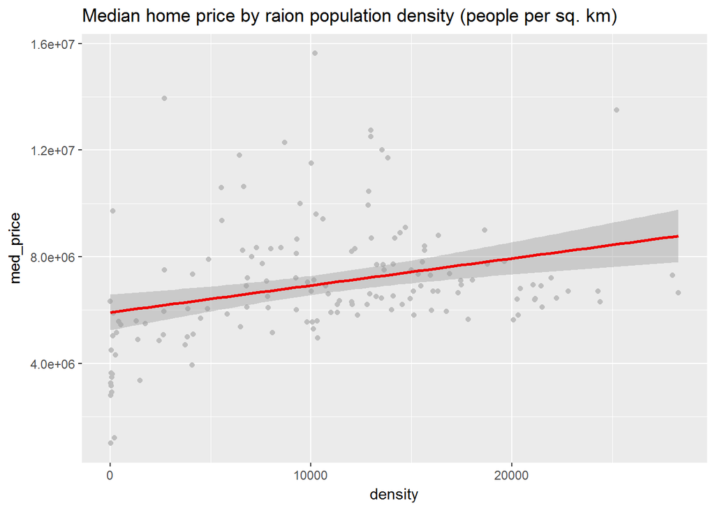

```r
train %>%
    mutate(area_km=area_m/1000000, density=raion_popul/area_km) %>%
    select(sub_area, density, price_doc) %>%
    group_by(sub_area) %>%
    summarize(density=median(density), med_price=median(price_doc)) %>%
    ggplot(aes(x=density, y=med_price)) +
    geom_point(color='grey') +
    geom_smooth(method='lm', color='red2') +
    ggtitle('Median home price by raion population density (people per sq. km)')
```

These density numbers seem to make sense given that the population density of Moscow as a whole is 8,537/sq km. There are a few raions that seem to have a density of near zero, which seems odd. Home price does seem to increase with population density.

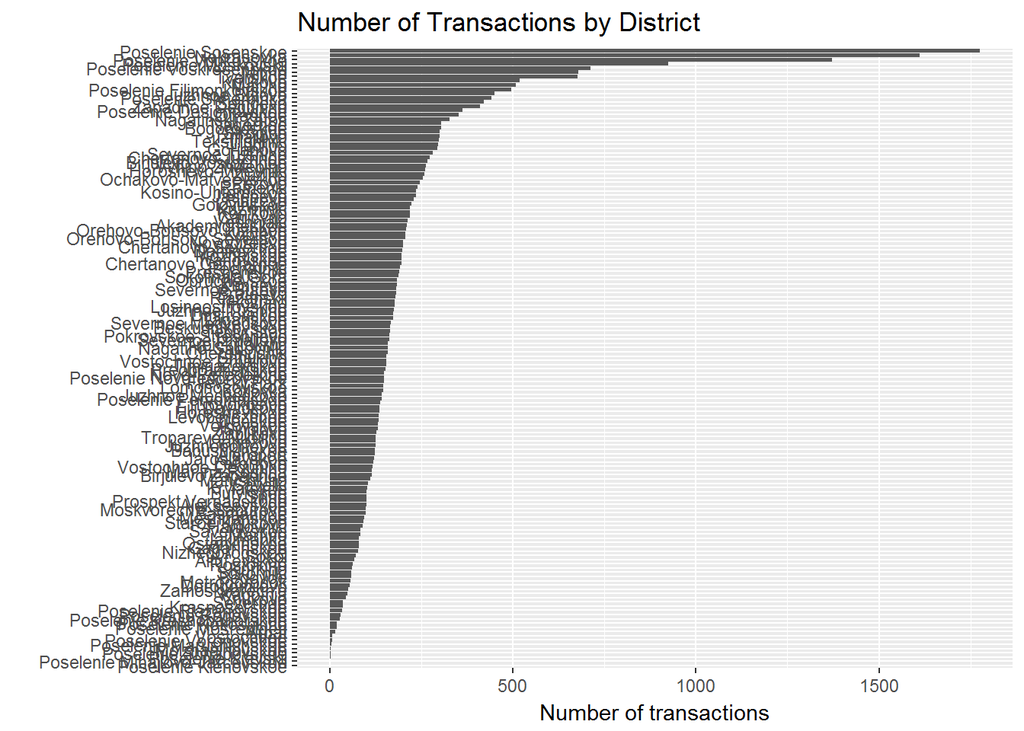

```r
train %>%
    group_by(sub_area) %>%
    summarize(n=n()) %>%
    ggplot(aes(x=reorder(sub_area, n), y=n)) +
    geom_bar(stat='identity') +
    coord_flip() +
    labs(y='Number of transactions', x='', title='Number of Transactions by District')
```

Poselenie Sosenskoe, Nekrasovka, Poselenie Vnukovskoe had the most transactions in the data set by a fairly large margin.

I wonder if there is a relationship between the share of the population that is working age and price.

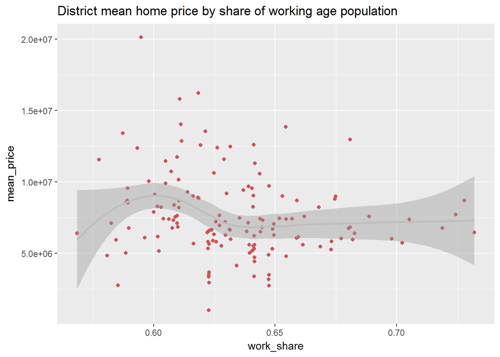

```r
train %>%
    mutate(work_share=work_all/raion_popul) %>%
    group_by(sub_area) %>%
    summarize(mean_price=mean(price_doc), work_share=mean(work_share)) %>%
    ggplot(aes(x=work_share, y=mean_price)) +
    geom_point(color='indianred3') +
    geom_smooth(color='gray') +
    ggtitle('District mean home price by share of working age population')
```

In the US, school quality is one of the primary determinants of home values.

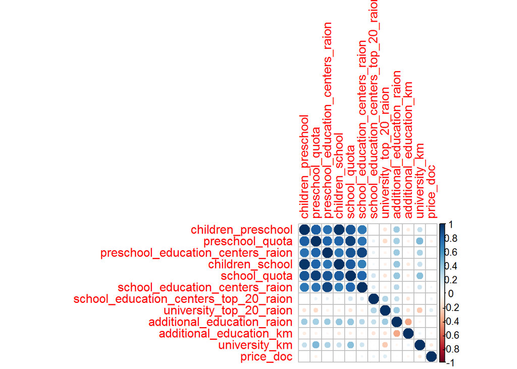

```r
school_chars <- c('children_preschool', 'preschool_quota', 'preschool_education_centers_raion',
                  'children_school', 'school_quota', 'school_education_centers_raion',
                  'school_education_centers_top_20_raion', 'university_top_20_raion',
                  'additional_education_raion', 'additional_education_km', 'university_km',
                  'price_doc')

corrplot(cor(train[, ..school_chars], use='complete.obs'))
```

there is little to no correlation between price and the school variables. The school variables however are highly correlated with each other, indicating that we would not want to use all of them in a linear regression model due to multicollinearity.

```r
table(train$university_top_20_raion)
```

```
##
##     0     1     2     3
## 27392  1994  1035    50
```

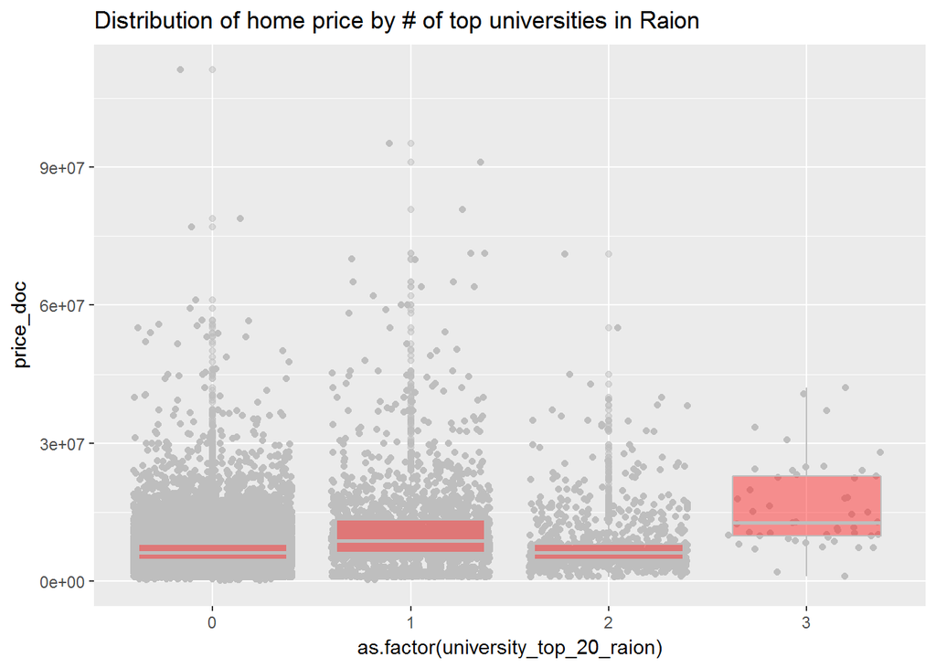

```r
train %>%
    ggplot(aes(x=as.factor(university_top_20_raion), y=price_doc)) +
    geom_jitter(color='grey') +
    geom_boxplot(fill='firebrick1', color='gray', alpha=0.5) +
    ggtitle('Distribution of home price by # of top universities in Raion')
```

```r
unique(train %>% filter(university_top_20_raion==3) %>% select(sub_area))
```

```
##         sub_area
## 1 Zamoskvorech'e
```

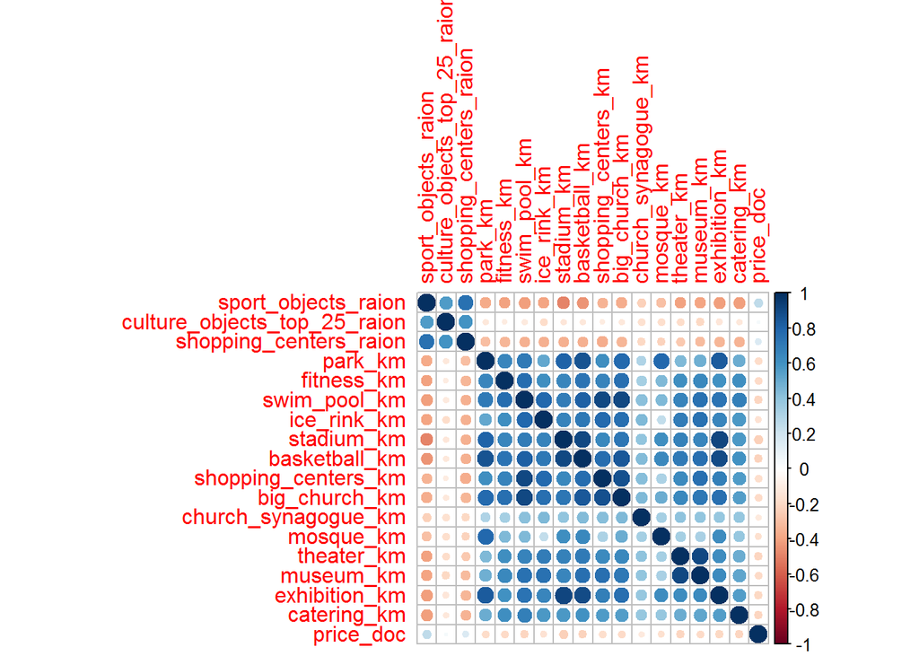

```r
cult_chars <- c('sport_objects_raion', 'culture_objects_top_25_raion', 'shopping_centers_raion',                        'park_km', 'fitness_km', 'swim_pool_km', 'ice_rink_km','stadium_km', 'basketball_km',                   'shopping_centers_km', 'big_church_km','church_synagogue_km', 'mosque_km', 'theater_km',                 'museum_km', 'exhibition_km', 'catering_km', 'price_doc')

corrplot(cor(train[, ..cult_chars], use='complete.obs'))
```

Let’s look at sport_objects.

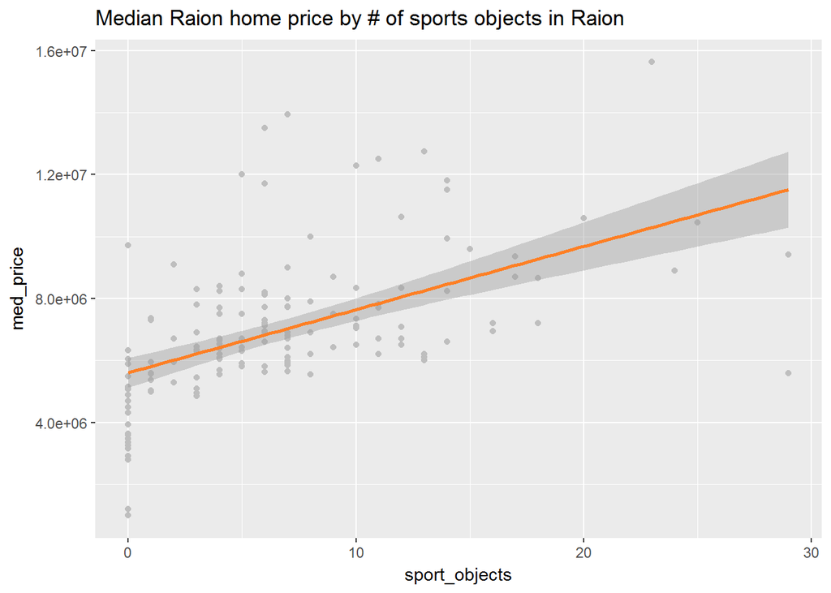

```r
train %>%
    group_by(sub_area) %>%
    summarize(sport_objects=mean(sport_objects_raion), med_price=median(price_doc)) %>%
    ggplot(aes(x=sport_objects, y=med_price)) +
    geom_point(color='grey') +
    geom_smooth(method='lm', color='chocolate1') +
    ggtitle('Median Raion home price by # of sports objects in Raion')
```

There is definitely a positive correlation. This could be a good candidate feature to include in a model.

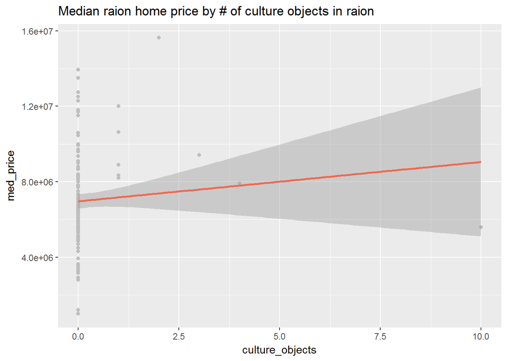

```r
train %>%
    group_by(sub_area) %>%
    summarize(culture_objects=mean(culture_objects_top_25_raion), med_price=median(price_doc)) %>%
    ggplot(aes(x=culture_objects, y=med_price)) +
    geom_point(color='grey') +
    geom_smooth(method='lm', color='coral2') +
    ggtitle('Median raion home price by # of culture objects in raion')
```

We can’t get much information out of this due to the large number of raions that have zero culture objects. What if we just see if there is a difference between raions with and raions without a top 25 culture object.

```r
train %>% group_by(culture_objects_top_25) %>%
    summarize(med_price=median(price_doc))
```

```
## # A tibble: 2 x 2
##   culture_objects_top_25 med_price
##   <chr>                      <dbl>
## 1 no                       6200000
## 2 yes                      7400000
```

How is the distance to the nearest park related to home price

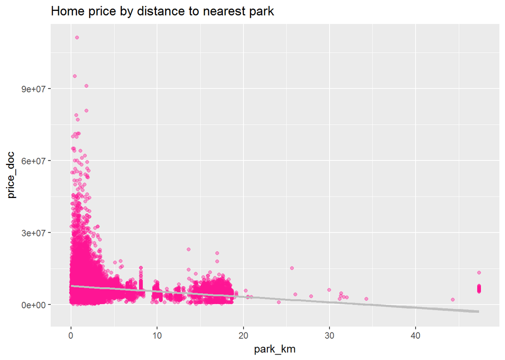

```r
ggplot(aes(x=park_km, y=price_doc), data=train) +
    geom_point(color='deeppink1', alpha=0.4) +
    geom_smooth(method='lm', color='grey') +
    ggtitle('Home price by distance to nearest park')
```

Infrastructure Features

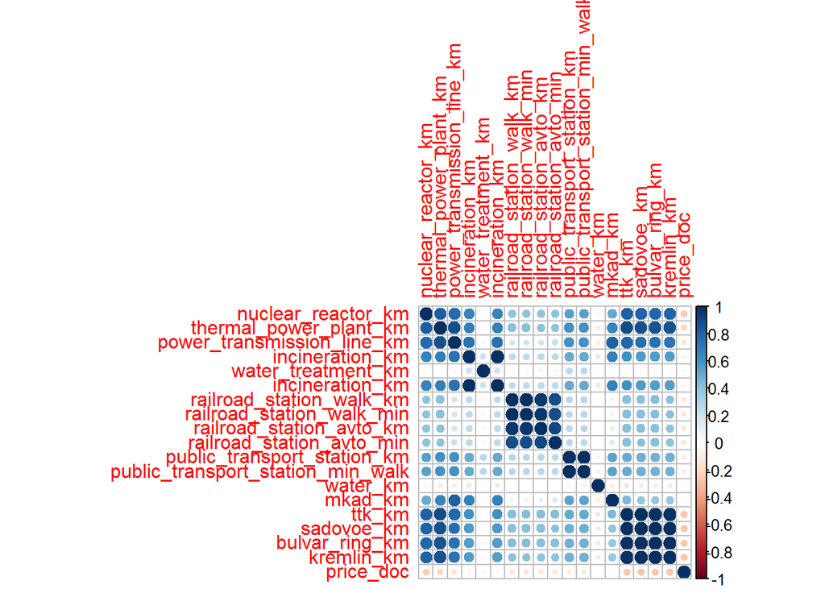

```r
inf_features <- c('nuclear_reactor_km', 'thermal_power_plant_km', 'power_transmission_line_km',
                  'incineration_km','water_treatment_km', 'incineration_km', 'railroad_station_walk_km',                   'railroad_station_walk_min', 'railroad_station_avto_km', 'railroad_station_avto_min',                    'public_transport_station_km', 'public_transport_station_min_walk', 'water_km',                          'mkad_km', 'ttk_km', 'sadovoe_km','bulvar_ring_km', 'kremlin_km', 'price_doc')

corrplot(cor(train[, ..inf_features], use='complete.obs'))
```

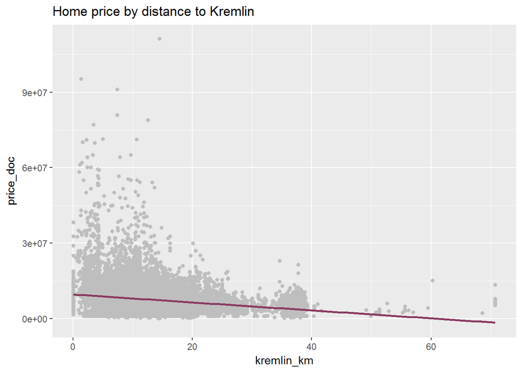

```r
ggplot(aes(x=kremlin_km, y=price_doc), data=train) +
    geom_point(color='grey') +
    geom_smooth(method='lm', color='hotpink4') +
    ggtitle('Home price by distance to Kremlin')
```

Test Data

```r
test <- fread("file:///C:/Users/Administrator/Desktop/Kaggle/pucho1/test.csv")
```

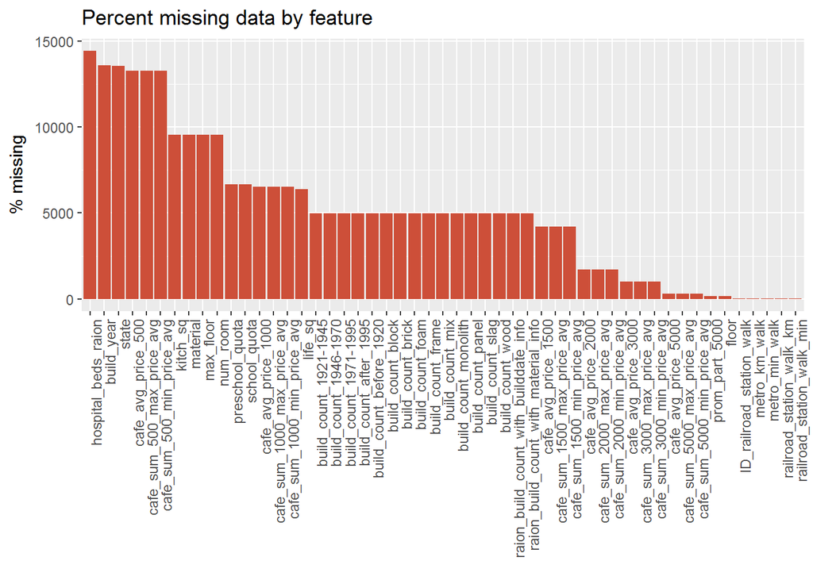

```r
miss_value1=sort(colSums(is.na(test)))
miss_value1 <- miss_value[miss_value>0]

data.frame(miss=miss_value1, var=names(miss_value1), row.names=NULL) %>%
    ggplot(aes(x=reorder(var, -miss), y=miss)) +
    geom_bar(stat='identity', fill='tomato3') +
    labs(x='', y='% missing', title='Percent missing data by feature') +
    theme(axis.text.x=element_text(angle=90, hjust=1))
```

```r
# remove price_doc from dtrain
train <- train %>%
    select(-price_doc) %>%
    mutate(dataset='train')

test <- test %>%
    mutate(dataset='test', timestamp=as.Date(timestamp))

all_data <- bind_rows(train, test)
```

Internal Home Features

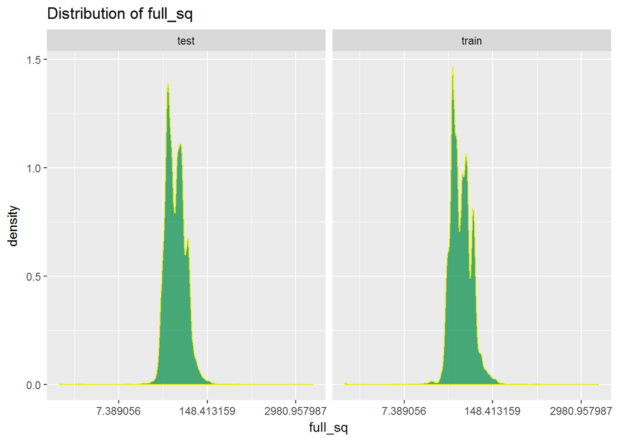

```r
all_data %>%
    ggplot(aes(x=full_sq)) +
    geom_density(color='yellow2', fill='springgreen4', alpha=0.7) +
    facet_wrap(~as.factor(dataset)) +
    scale_x_continuous(trans='log') +
    ggtitle('Distribution of full_sq')
```